# Introduction to R, Part 2: Data Frames, Reading Data, visualizing data with ggplot2

Ted Laderas!

## Assignment (10 points)

Instructions: Turn your `.nb.html` file in with the following assignment finished. Make sure it is named `part2_LASTNAME.nb.html`, where `LASTNAME` is your last name, of course.

1. Load the `smoke_complete.xlsx` file into R using `read_excel`. You’ll need to take a look at it to make sure that your arguments are correct.

```r
library(tidyverse)
library(readxl)
smoke_complete <- read_excel("data/smoke_complete.xlsx", sheet=1, na ="NA")
```

2. Use `glimpse()` on `smoke_complete`. How many rows does the file have? How many variables does it have? What are the numeric variables in this dataset?

```r
glimpse(smoke_complete)
```

```
## Rows: 1,152
## Columns: 20
## $ primary_diagnosis           <chr> "C34.1", "C34.1", "C34.3", "C34.1", "C3...
## $ tumor_stage                 <chr> "stage ia", "stage ib", "stage ib", "st...
## $ age_at_diagnosis            <dbl> 24477, 26615, 28171, 27154, 23370, 1902...
## $ vital_status                <chr> "dead", "dead", "dead", "alive", "alive...
## $ morphology                  <chr> "8070/3", "8070/3", "8070/3", "8083/3",...
## $ days_to_death               <dbl> 371, 136, 2304, NA, NA, 345, 716, 2803,...
## $ state                       <chr> "live", "live", "live", "live", "live",...
## $ tissue_or_organ_of_origin   <chr> "C34.1", "C34.1", "C34.3", "C34.1", "C3...
## $ days_to_birth               <dbl> -24477, -26615, -28171, -27154, -23370,...
## $ site_of_resection_or_biopsy <chr> "C34.1", "C34.1", "C34.3", "C34.1", "C3...
## $ days_to_last_follow_up      <dbl> NA, NA, 2099, 3747, 3576, NA, NA, 1810,...
## $ cigarettes_per_day          <dbl> 10.9589041, 2.1917808, 1.6438356, 1.095...
## $ years_smoked                <dbl> NA, NA, NA, NA, NA, NA, NA, NA, NA, 26,...
## $ gender                      <chr> "male", "male", "female", "male", "fema...
## $ year_of_birth               <dbl> 1936, 1931, 1927, 1930, 1942, 1953, 193...
## $ race                        <chr> "white", "asian", "white", "white", "no...
## $ ethnicity                   <chr> "not hispanic or latino", "not hispanic...
## $ year_of_death               <dbl> 2004, 2003, NA, NA, NA, 2005, 2006, NA,...
## $ bcr_patient_barcode         <chr> "TCGA-18-3406", "TCGA-18-3407", "TCGA-1...
## $ disease                     <chr> "LUSC", "LUSC", "LUSC", "LUSC", "LUSC",...
```

There are 8 numeric variables in this dataset (they are called `dbl`, which is short for double, which is a numeric datatype).

The numeric variables are:

- `age_at_diagnosis`
- `days_to_death`
- `days_to_birth`
- `days_to_last_follow_up`
- `cigarettes_per_day`
- `years_smoked`
- `year_of_birth`
- `year_of_death`
3. Produce a scatter plot of `smoke_complete` using `geom_point()`, mapping these variables to the following aesthetics:

`year_of_birth` to the `x` aesthetic, `cigarettes_per_day` to the `y` aesthetic, and `gender` to the `color` aesthetic.

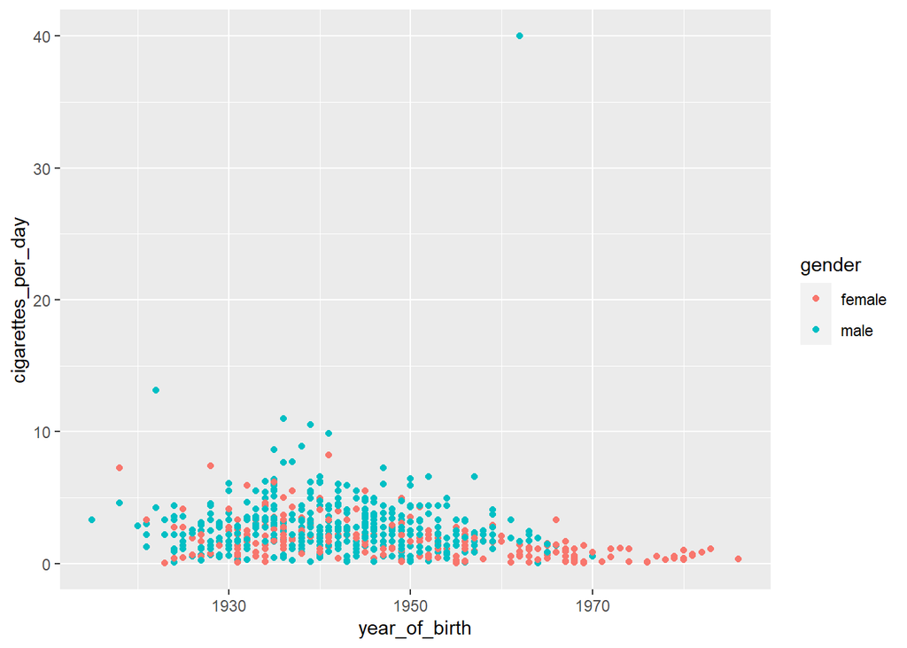

```r
ggplot(smoke_complete, aes(x = year_of_birth,
                           y = cigarettes_per_day,
                           color = gender)) +
geom_point()
```

4. Pick two `numeric` variables, and a character variable in the dataset and produce a scatterplot by mapping them to `x`, `y`, and `color`. Add a title and change the x and y labels to make sense.

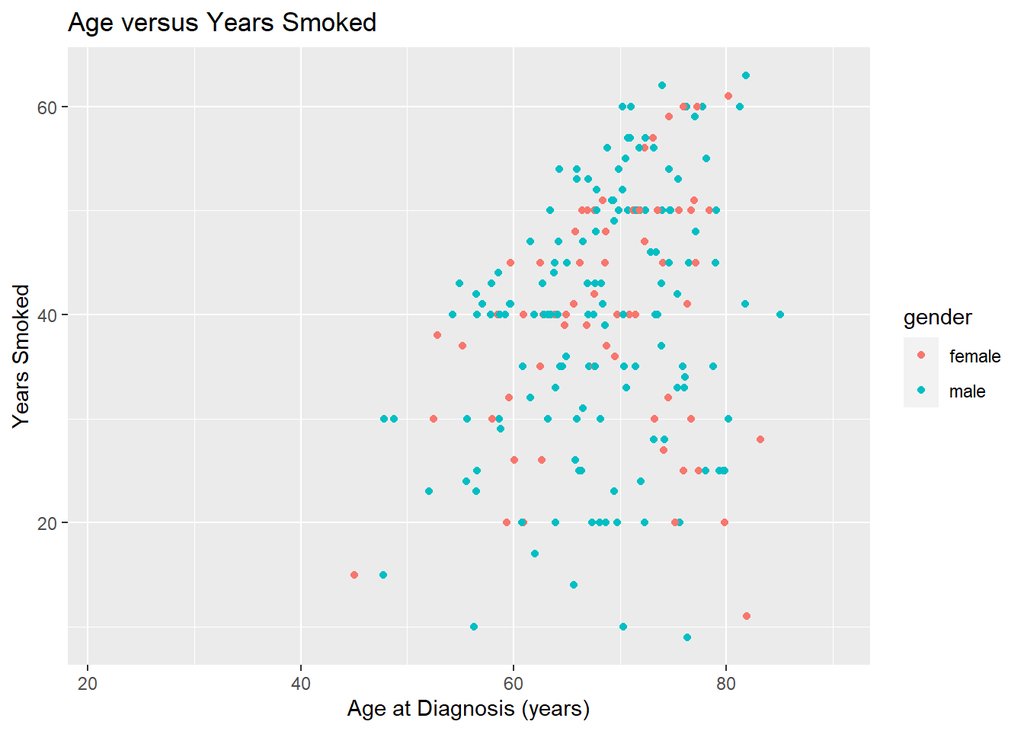

```r
ggplot(smoke_complete) +
  aes(x=age_at_diagnosis/365, y=years_smoked, color = gender) +
  geom_point() +
  xlab("Age at Diagnosis (years)") +
  ylab("Years Smoked") +
  ggtitle("Age versus Years Smoked")
```